# Use Cases & End-to-End Journeys

# Use Cases & End-to-End Journeys

**Revision:** 1 **Last modified:** 2026-06-26T12:00:00Z

> **Document role.** This is the Volume 1 (Product & Requirements) nano-detail spec enumerating HelixVPN's primary **end-to-end use cases**, each rendered as a step-by-step **journey** with a Mermaid sequence diagram, explicit preconditions and postconditions, and the exact **components and APIs** exercised. It turns the three roles, seven principles, and parity matrix of the Volume 1 overview (`00-product-scope-and-principles.md`) into runnable narratives that the §11.4.169 test types and the 8-criteria MVP DoD trace onto.

> **Document is a SPEC.** It describes *what the user does and what the system does in response*; it does not build the product. Each journey is a candidate e2e / full-automation test scenario (§11.4.98 — fully self-driving, no manual step after start) and is written so its postconditions are captured-evidence assertions, not prose claims (§11.4 / §11.4.69).

> **Evidence base.** Cross-references the Volume 1 overview (roles §3, two-way / multi-network §4, parity matrix §9, scope §10, decisions D1/D4/D6), the coordinator streaming contract (`v03-control-plane/svc-coordinator.md` — `WatchNetworkMap`, the < 1 s convergence + revoke SLOs, the reaction table), the telemetry presence + audit model (`v03-control-plane/svc-telemetry.md`), the no-logging invariant (`v05-security/no-logging-as-code.md`), and the transport escalation ladder (`v02-data-plane/transport-selection-ladder.md`). Research is cited by the overview's ids (`[04_ARCH §N]`, `[04_P1]`). Anything unproven is marked `UNVERIFIED` per §11.4.6.
- 1. Use-case catalogue & actor model
- 2. UC-01 — Consumer first connect (privacy exit)
- 3. UC-02 — Switch exit / server
- 4. UC-03 — Enable multihop
- 5. UC-04 — Business admin enrolls a device & sets policy
- 6. UC-05 — Connector advertises a route
- 7. UC-06 — Censorship-evade via transport escalation
- 8. UC-07 — Kill-switch trips on network drop
- 9. Cross-cutting postcondition invariants
- 10. Use-case → component → API → test traceability
- Sources verified

## 1. Use-case catalogue & actor model

The actors are the three roles of the overview plus the human personas (`00-...` §3, §5).

| Actor | Role / persona | App |
| --- | --- | --- |
| **End user** | Mullvad-style privacy/lab user | Helix Access |
| **Network operator** | exposes a LAN safely | Helix Connector (daemon) |
| **Admin** | manages tenants/users/devices/policy | Helix Console |
| **Gateway control plane** | Go (identity/registry/ipam/pki/policy/coordinator/events/telemetry/api) | server |
| **Gateway edge** | Rust data plane (transports + WireGuard) | server |

| UC | Title | Primary actor | Phase | Parity / differentiator |
| --- | --- | --- | --- | --- |
| UC-01 | Consumer first connect (privacy exit) | End user | MVP | F1, F7, F14 |
| UC-02 | Switch exit / server | End user | MVP | F1, X1 |
| UC-03 | Enable multihop | End user | P2 | F10 |
| UC-04 | Admin enrolls a device & sets policy | Admin | MVP | F15, F17, X1 |
| UC-05 | Connector advertises a route | Network operator | MVP | X1, X2 |
| UC-06 | Censorship-evade via transport escalation | End user | MVP | F2, F6, F7, F8 |
| UC-07 | Kill-switch trips on network drop | End user | MVP | F11, F13 |

Each journey below maps to the MVP Definition-of-Done acceptance criteria of the overview §10.2 where applicable, and each is a §11.4.98-compliant fully-automatable e2e scenario (no human step after start; non-introspectable UI falls back to the §11.4.117 pixel oracle).

## 2. UC-01 — Consumer first connect (privacy exit)

**Goal.** A new end user installs Access, enrolls anonymously (no email), and gets a full-tunnel privacy exit to the internet — the Mullvad use case.

**Preconditions.**

- A reachable Gateway (self-hosted or managed) with a public endpoint.
- An enrollment token (anonymous device-token path, no PII) OR an OIDC login.
- Access app installed on a supported platform (iOS/Android/Linux for MVP).

**Postconditions (captured-evidence assertions).**

- The device holds an overlay IP and a short-lived mTLS device cert.
- A WireGuard tunnel is established; the chosen exit carries the device's internet traffic (full-tunnel).
- A `presence:{tenant}:{device}` key exists in Redis (TTL'd); **no** durable connection row exists (NFR-300 / no-logging).
- An `device.enrolled` audit row exists (control action); **no** traffic audit.

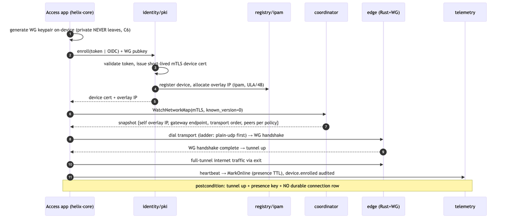

**Honest boundary (§11.4.6).** On iOS the tunnel runs inside the NE memory ceiling (NFR-500) — first-connect on iOS is gated by Phase-0 G3 and is `UNVERIFIED` until that on-device capture exists. The journey's logic is platform-neutral; the iOS resource fit is the open risk, not the flow.

## 3. UC-02 — Switch exit / server

**Goal.** A connected user picks a different exit (privacy server) or a different joined network, and traffic re-routes without dropping the app session.

**Preconditions.** UC-01 complete (device connected, has overlay IP + cert). The target exit/network is one the device's policy grants (need-to-know, C4).

**Postconditions.**

- The new exit/network carries traffic; the old one no longer does.
- Convergence to the new route is **< 1 s** (NFR-003) via a `MapDelta`, with **no** client restart (DoD-5 spirit).
- The kill-switch never opens a leak during the transition (NFR-404).

**Components / APIs.** Access UI (`helix-ui` ExitPicker), `helix-core` (re-pin/reconnect), `coordinator` (delta), `edge` (re-route), `policy` (VisibleTo / AllowedIPs).

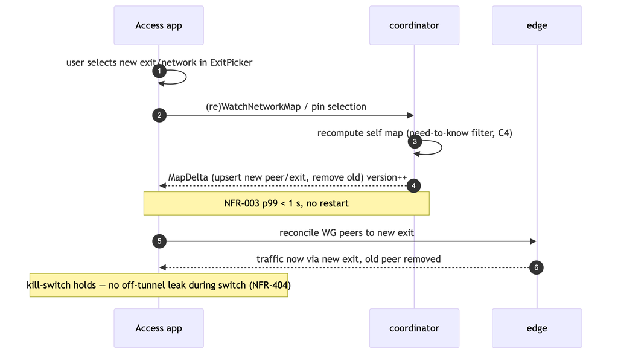

> **Need-to-know enforcement (C4).** The user can only switch to an exit/network their compiled policy grants — a non-granted target never appears in the snapshot (NFR-402), so the UI cannot offer it. This is the multi-network (X1) differentiator surfacing as a routing choice.

## 4. UC-03 — Enable multihop

**Goal.** A privacy-conscious user enables entry/exit separation (multihop) so the entry node never sees the exit destination and vice-versa (parity F10). Phase 2.

**Preconditions.** P2 multihop available; user connected (UC-01). The tenant's policy/topology offers ≥2 hops in distinct jurisdictions.

**Postconditions.**

- Traffic traverses nested WireGuard (entry → exit), control-plane orchestrated.
- No single hop holds both the user identity and the destination.
- Latency rises (extra hop) within the obfuscation-aware budget (NFR-007) — exact added latency `UNVERIFIED` (P2 benchmark owns it).

**Components / APIs.** Access UI (multihop toggle), `helix-core` (nested WG), `coordinator` (per-hop keys in the map), `policy` (hop authorization), `edge`.

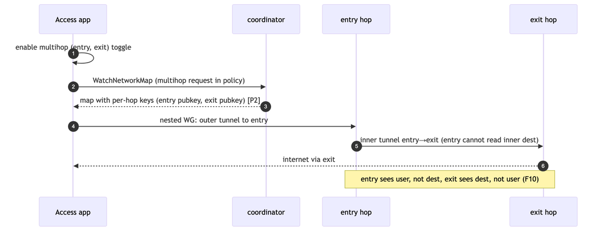

> **Phase boundary (§11.4.6).** Multihop is explicitly OUT of MVP scope (overview §10.2 → P2). This journey is the P2 contract; its postconditions are `UNVERIFIED` until the P2 nested-WG implementation and its e2e capture exist.

## 5. UC-04 — Business admin enrolls a device & sets policy

**Goal.** An admin (Console) creates a user/device enrollment, then writes a default-deny ACL granting a group access to a specific network/port — reflected on the edge in **< 1 s** with no restart.

**Preconditions.** Admin authenticated to Console (RBAC `admin`/`operator`). A tenant exists; at least one connector has advertised a network (UC-05).

**Postconditions.**

- An enrollment token is minted (audited `enroll_token.mint`); the device enrolls (UC-01) and appears in the registry.
- A policy edit (`group:contractors → net:warehouse:554/tcp`) compiles to per-peer `AllowedIPs` + an edge verdict map and reaches affected agents in **< 1 s** (NFR-003 / DoD-5).
- Audit holds `policy.create` + `policy.activate` control rows; **no** traffic.

**Components / APIs.** Console (`helix-ui` admin + REST `/v1/...`), `api` (Gin REST + WS/SSE), `identity` (enroll token), `policy` (compiler), `coordinator` (fan-out), `telemetry` (audit).

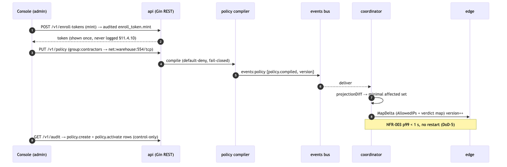

> **Authorization boundary.** `GET /v1/audit` requires `admin`/`operator`; `member` is denied; RLS is the floor so even a mis-scoped query returns only the caller's tenant rows (NFR-408). The minted token is shown once and never logged (§11.4.10).

## 6. UC-05 — Connector advertises a route

**Goal.** A network operator installs the Connector daemon inside a private LAN; it dials **outbound** to the Gateway and advertises the LAN's CIDRs — no inbound port-forward, ever (P3 / X2).

**Preconditions.** Connector daemon installed on a host inside the LAN. An enrollment token for the connector. Outbound reachability to the Gateway.

**Postconditions.**

- The connector holds a device cert + overlay identity and an attached `site` (4via6 site id, D4).
- Its advertised CIDRs are registered; authorized users' maps gain reachable peers/routes for that network.
- Overlapping RFC1918 ranges across connectors are disambiguated by the overlay addressing scheme (ULA /48 + 4via6 / per-network NAT fallback, D4).
- **No** inbound port was opened on the LAN's router (P3 assertion).

**Components / APIs.** Connector (`helix-core` advertise/route mode), `identity` /`pki`, `registry` (`route.advertised`), `ipam` (site), `coordinator` (reaction `connector.attached` / `connector.prefixes.changed`), `policy`.

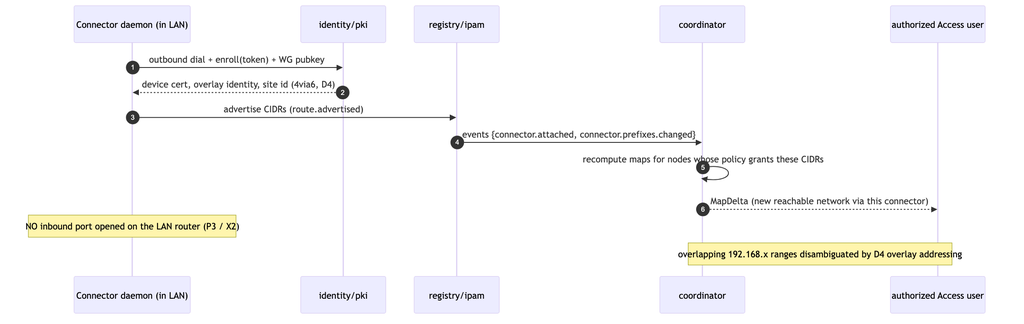

> **Conflict handling (§11.4.6).** Two connectors advertising the same RFC1918 range raise `route.conflict.detected`; the coordinator does **not** push a delta for it — the conflict surfaces to Console and 4via6 site disambiguation resolves it (D4). The concrete addressing scheme is frozen in the Phase-1 IPAM design; until then the collision resolution detail is `UNVERIFIED`.

## 7. UC-06 — Censorship-evade via transport escalation

**Goal.** A user on a censored network where plain WireGuard/UDP is blocked automatically escalates the transport ladder until an obfuscated rung (MASQUE/QUIC) carries the WG handshake — Mullvad's "automatic obfuscation" (F7), looking like ordinary web traffic.

**Preconditions.** Device enrolled (UC-01). The current network blocks plain-UDP WG (DPI / UDP block). The ladder order is the default or a coordinator-pushed regional prior.

**Postconditions.**

- The ladder advances monotonically within the attempt (L-I8) until a rung completes a **WG handshake** (carrier-connect alone is not success, I2).
- The working rung is remembered per-network (fingerprint hash + rung index, **no** SSID plaintext, **no** endpoint, no per-connection log — I5).
- Aggregate escalation telemetry is recorded (counts only, no per-user flow).
- Throughput on the obfuscated rung meets the DPI-survival bar (NFR-002 ≥ 50 % of plain — TARGET `UNVERIFIED` until G2).

**Components / APIs.** `helix-core` ladder (`ladder.rs`), `helix-transport` (plain-udp / lwo / masque-h3 / …), `edge` (transport termination), `coordinator` (`TransportPolicy.order` regional prior), `telemetry` (aggregate ladder outcomes).

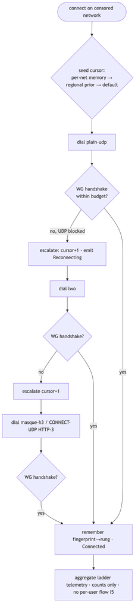

> **No-logging on the evade path (§11.4.6).** Per-network memory persists only a fingerprint *hash* + last-good rung index — never the SSID, never the server endpoint, never a timestamped per-connection record (I5). The escalation event trace IS the captured evidence (L-I9), and it carries no destination. The ≥ 50 % DPI-survival throughput is a TARGET pending Phase-0 G2.

## 8. UC-07 — Kill-switch trips on network drop

**Goal.** The user's underlying network drops (or the tunnel fails); the kill-switch blocks all off-tunnel traffic so nothing leaks, and DNS stays forced through the tunnel (F11 + F13).

**Preconditions.** Device connected with kill-switch enabled (default-on for the privacy posture). The OS firewall integration is active (`helix-core` state machine + per-OS firewall driver).

**Postconditions.**

- On tunnel-down, **0** packets traverse the physical interface off-tunnel (NFR-404 leak test).
- **0** plaintext DNS queries escape off-tunnel (NFR-405).
- On reconnect (ladder re-runs, UC-06), the kill-switch lifts only once a tunnel is re-established — never a leak-window during the gap.

**Components / APIs.** `helix-core` (kill-switch + DNS state machine), per-OS firewall shim (nftables/WFP/NE rules), `coordinator` (reconnect map), `edge`.

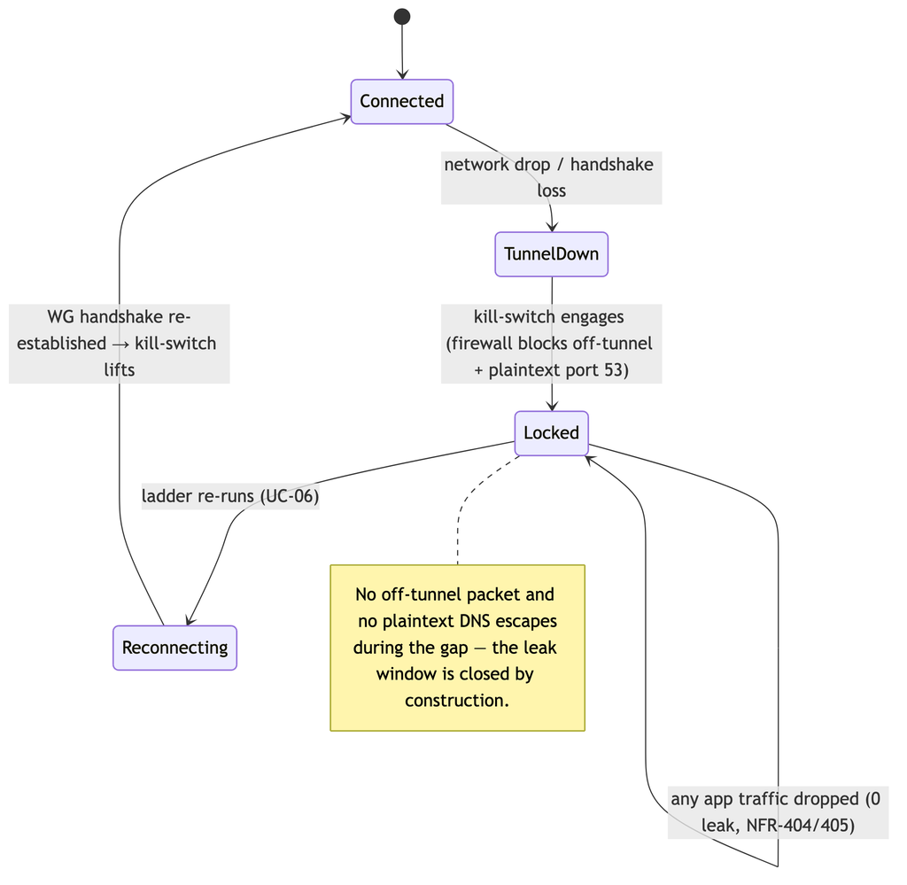

> **Verification (§11.4.69).** The kill-switch postconditions are proven by a packet-capture leak test on the physical interface during a forced tunnel-drop: a non-zero off-tunnel packet count is a FAIL. The capture IS the evidence; "no leak observed" without the capture is a PASS-bluff (§11.4).

## 9. Cross-cutting postcondition invariants

Every journey above, regardless of actor, must leave the system in a state that satisfies these invariants — they are the union of the seven principles and the no-logging guarantee surfacing as per-journey postconditions:

| Invariant | Holds in every journey because | Verified by |
| --- | --- | --- |
| **Fail-static (P1)** | the edge forwards from a cached verdict map; a control-plane blip during any journey never drops an established tunnel | chaos (kill control plane mid-journey) |
| **Outbound-only (P3)** | every actor *dials out*; the gateway is the only public listener | security (no-inbound assertion) |
| **Need-to-know (C4)** | every map a journey delivers is policy-filtered; a non-granted peer never appears | meta-test (skip-filter mutation FAILs) |
| **< 1 s convergence (P4)** | every map change in a journey is a minimal `MapDelta` | performance (`helix_reconcile_seconds`) |
| **No-logging (P7)** | no journey writes a durable connection/traffic row; presence is ephemeral; audit is control-only | security (schema-lint, deployed DB) |
| **Anonymous identity (F15)** | first-connect (UC-01) needs no email/SSO | integration (anonymous enroll) |

> **Anti-bluff coupling (§11.4 / §11.4.98).** Each journey is authored as a fully self-driving e2e scenario: no human action after start, deterministic across re-runs (§11.4.50), captured evidence per postcondition. A journey that "passes" without its postcondition captures (presence key present, no durable row, delta on wire, zero leak) is a PASS-bluff at the use-case layer.

## 10. Use-case → component → API → test traceability

| UC | Components | Key APIs / streams | DoD / NFR | §11.4.169 test type |
| --- | --- | --- | --- | --- |
| UC-01 | identity, pki, registry, ipam, coordinator, core, edge, telemetry | enroll; `WatchNetworkMap`; transport dial | DoD-1/2, NFR-307/304 | e2e / full-automation |
| UC-02 | core, coordinator, edge, policy | `WatchNetworkMap` delta | DoD-5, NFR-003/402 | e2e |
| UC-03 | core, coordinator, edge, policy | map w/ per-hop keys (P2) | F10, NFR-007 | e2e (P2) |
| UC-04 | api, identity, policy, coordinator, telemetry | REST `/v1/...`; events:policy; audit | DoD-3/5, NFR-003/408 | e2e + integration |
| UC-05 | core, identity, pki, registry, ipam, coordinator, policy | `route.advertised`; `connector.attached` | X1/X2, NFR-103/104 | e2e + integration |
| UC-06 | core (ladder), transport, edge, coordinator, telemetry | ladder; `TransportPolicy.order` | DoD-4, NFR-002/410/006 | e2e (DPI-sim) |
| UC-07 | core (kill-switch/DNS), firewall shim, coordinator, edge | firewall state machine | DoD-7, NFR-404/405 | security / e2e (leak test) |

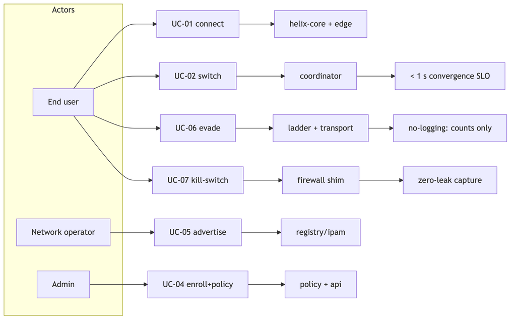

> **Phase honesty (§11.4.6).** UC-01/02/04/05/06/07 are MVP-scoped; UC-03 (multihop) is P2. P2/P3 postconditions are `UNVERIFIED` until their phase's implementation and captured e2e evidence exist — they are the forward contract, never asserted as already working.

## Sources verified

- `docs/research/mvp/final/00-product-scope-and-principles.md` — three roles + control relationships (§3), two-way / multi-network exact meaning (§4), personas + app classes (§5), Mullvad-parity matrix F1–F17 + X1–X5 (§9), phase scope + 8-criteria MVP DoD (§10), decisions D1 (MASQUE)/D4 (ULA+4via6)/D6 (asymmetric per-leg) (§11).
- `docs/research/mvp/final/v03-control-plane/svc-coordinator.md` — the `WatchNetworkMap` streaming handler, `known_version` resume, the reaction table (`device.enrolled`/`device.revoked`/`connector.attached`/ `connector.prefixes.changed`/`policy.compiled`), need-to-know `VisibleTo` filtering (C4), the < 1 s convergence + < 1 s revoke SLOs (§7).
- `docs/research/mvp/final/v03-control-plane/svc-telemetry.md` — ephemeral Redis presence (MarkOnline/Refresh/Offline, TTL), the control-action audit vocabulary
  - meta-shape guard, counts-only metrics.
- `docs/research/mvp/final/v05-security/no-logging-as-code.md` — the no-logging postcondition invariants (no durable connection row, presence ephemeral, audit control-only) every journey must satisfy.
- `docs/research/mvp/final/v02-data-plane/transport-selection-ladder.md` — the escalation ladder behind UC-06 (seed order, monotonic cursor L-I8, WG-handshake success criterion I2, per-network memory + no-logging I5, aggregate telemetry).

*Constitution bindings applied: §11.4.44 (revision header), §11.4.6 (no-guessing — P2/P3 postconditions + unproven targets marked `UNVERIFIED`), §11.4.98 (every journey authored as a fully self-driving e2e scenario, no manual step after start), §11.4.50 (deterministic re-run), §11.4.69/§11.4.107 (each postcondition is a captured-evidence assertion), §11.4.117 (pixel-oracle fallback for non-introspectable UIs), §11.4.25 (use-case → component → test coverage ledger §10), §11.4.65/§11.4.153 (HTML+PDF[+DOCX] exports follow in refinement).*